# Effects of spring weather conditions on bat growth

Alona Prylutska

08 March, 2024

# How weather conditions during pregnancy and lactation of bats influence subadult bats development?

Here, we hypothesize that bat growth might depend on spring weather conditions. To check that, we check, within a subadults of Noctule bats, if there are differences in growth rate among years. We also looked for optimal growth metric covered infra-survey variation.

# Material & Methods

## Bat Capture and Monitoring

Bats were captured during July in the years 2008, 2011, 2014, and 2019 as part of a bat monitoring program of the National Nature Park “Homilshansky lisy”, located in the Kharkiv Oblast, Ukraine. The capture methodology involved the use of nylon mist nets (12 х 3 meters, mesh size - 15 mm). Mist nets were consistently deployed at the same 9 locations each year of the monitoring. A total of 18 capture nights were conducted annually, with mist nets set from sunset until sunrise. Body weight measurements, rounded to the nearest 0.1 gram, and forearm length measurements, rounded to the nearest 0.1 millimeter, were obtained within 8-10 hours following the capture events.

Data collected during the capture process included bat species identification, sex and age determination. Age classification was primarily based on the degree of ossification observed in the joints of the finger phalanx of the wing, the size and morphology of nipples for female bats, and for *Nyctalus noctula* specifically, the wear pattern of canine teeth. All captured bats underwent biometric assessments before being promptly released back into their natural habitat. All procedures involved in the capture, handling, and transportation of bats were conducted with strict adherence to ethical standards and principles of animal welfare and conservation, as outlined by Gannon (2007).

Weather Data Acquisition and Analysis: Weather data, encompassing precipitation (Prcp), minimum temperature (Tmin), and maximum temperature (Tmax), for the study area were obtained using the easyclimate R package. Additional weather variables, including diurnal temperature range, mean daily temperature, positive daily temperature, and Growing Degree Units (the sum of mean daily temperatures above 0°C from the commencement of the year), were computed for further analysis.

The analysis focused on two distinct periods deemed crucial for bat growth: the spring period, spanning from March 25th to May 24th, characterized as the pre-natal phase for bat pups, and the summer period, extending from May 25th to June 24th, considered as the early post-natal phase preceding the captures. Due to the occurrence of a leap year in 2008, adjustments were made for Julian days accordingly.

Research Question and Hypotheses: Whether weather conditions during the periods of pregnancy and lactation influence the growth of young bats? It was hypothesized that years characterized by warmer and drier conditions during spring would correspond to larger sizes in subadult bats.

## Data preparation

Take a look at the data

```
##      Place                      Species        sex       age
##  Fed2   :403   Nyctalus noctula     :907   female:999   ad :644
##  Fed1   :288   Myotis daubentonii   :213   male  :526   sad:881
##  F1     :176   Pipistrellus nathusii:161
##  Fed3   :147   Pipistrellus pygmaeus:147
##  R1     :129   Nyctalus leisleri    : 48
##  F2     :120   Plecotus auritus     : 18
##  (Other):262   (Other)              : 31
##        Ra              W             ring                date
##  Min.   :27.00   Min.   : 2.60   Length:1525        Min.   :2008-07-02
##  1st Qu.:37.00   1st Qu.: 7.40   Class :character   1st Qu.:2008-07-13
##  Median :53.00   Median :21.30   Mode  :character   Median :2011-07-13
##  Mean   :46.86   Mean   :18.37                      Mean   :2012-06-29
##  3rd Qu.:54.70   3rd Qu.:27.20                      3rd Qu.:2014-07-11
##  Max.   :58.60   Max.   :37.50                      Max.   :2019-07-18
##
##    Year          day
##  2008:495   Min.   :182.0
##  2011:505   1st Qu.:186.0
##  2014:246   Median :191.0
##  2019:279   Mean   :190.6
##             3rd Qu.:194.0
##             Max.   :199.0
##
```

Check age structure among species

```
##
##                          ad sad
##   Eptesicus serotinus     6   4
##   Myotis brandtii         4   7
##   Myotis dasycneme        1   1
##   Myotis daubentonii     90 123
##   Nyctalus leisleri      34  14
##   Nyctalus noctula      374 533
##   Pipistrellus kuhlii     3   0
##   Pipistrellus nathusii  42 119
##   Pipistrellus pygmaeus  77  70
##   Plecotus auritus       12   6
##   Vespertilio murinus     1   4
```

Select only subadult Noctule bats

```r
# Subset only some species (e.g., N.noc. , M.daubentonii)
df <- subset(df,
              Species %in% c('Nyctalus noctula'
                              #,'Myotis daubentonii'
                             ) &
                age == "sad"
              )

summary (df)
```

```
##      Place                    Species        sex       age            Ra
##  Fed2   :172   Nyctalus noctula   :533   female:286   ad :  0   Min.   :47.80
##  Fed1   : 95   Eptesicus serotinus:  0   male  :247   sad:533   1st Qu.:53.30
##  F1     : 75   Myotis brandtii    :  0                          Median :54.10
##  F2     : 66   Myotis dasycneme   :  0                          Mean   :54.06
##  R2     : 59   Myotis daubentonii :  0                          3rd Qu.:55.00
##  R1     : 23   Nyctalus leisleri  :  0                          Max.   :58.10
##  (Other): 43   (Other)            :  0
##        W             ring                date              Year
##  Min.   :14.20   Length:533         Min.   :2008-07-02   2008:157
##  1st Qu.:21.00   Class :character   1st Qu.:2008-07-14   2011:214
##  Median :23.30   Mode  :character   Median :2011-07-13   2014: 81
##  Mean   :23.13                      Mean   :2012-04-24   2019: 81
##  3rd Qu.:25.50                      3rd Qu.:2014-07-10
##  Max.   :30.30                      Max.   :2019-07-18
##
##       day
##  Min.   :182.0
##  1st Qu.:187.0
##  Median :194.0
##  Mean   :192.2
##  3rd Qu.:196.0
##  Max.   :199.0
##
```

Since we have nights (“days”) with very few bats captured, we decided to drop the nights with less then 10 bats.

```r
df <- df |>
  # count bats per day
  count(date) |>
  # choose days where more than 10 bats
  filter(n > 10) |>
  # subset with days where more than 10 bats
  inner_join(df)
```

## Exploration of the dynamics of growth metrics

How Ra related to W?

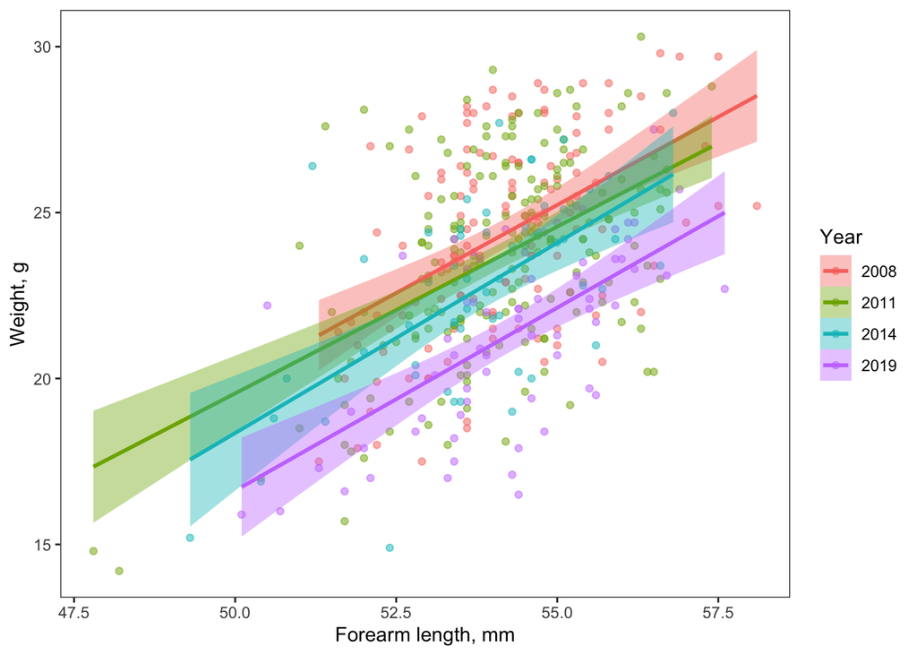

Bats with bigger forearm (Ra) have higher mass (W), and vice versa, regardless of year of capture.

Is there any sex differences in growth metrics? Is that possible that male and female bats growth different?

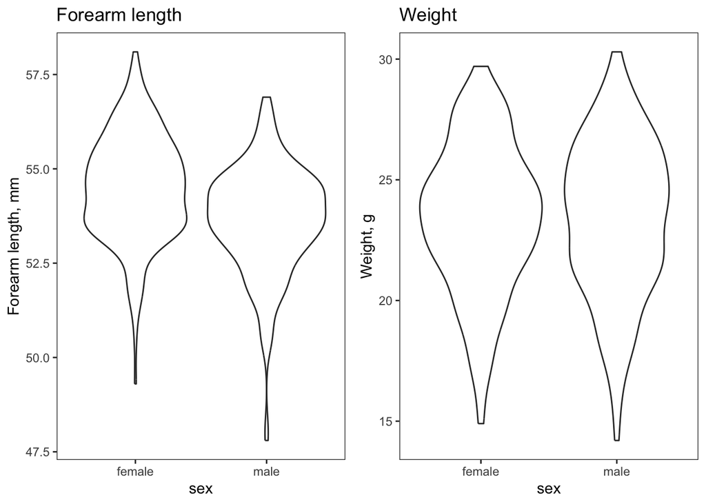

Ra might be slightly sex-dependent, Weight does not show such pattern.

Does Ra or W seem to be different among years?

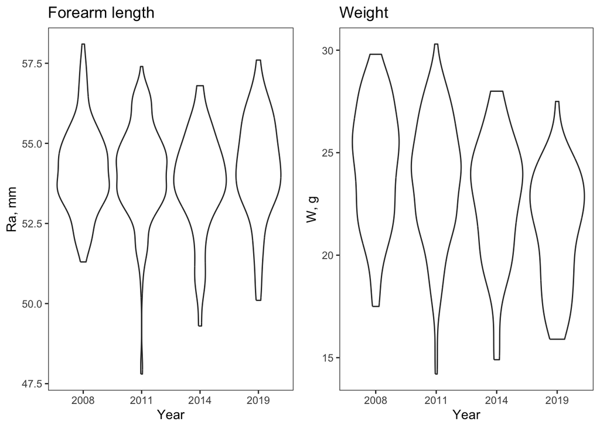

In our data set, Ra seems to be constant across the years of survey. Contrary, W tends to vary among years. Therefore, to test our hypothesis about spring weather effect on bat growth, we must apply weight-related metric of growth, not Ra-related.

Does Ra or W changes over the inventory time?

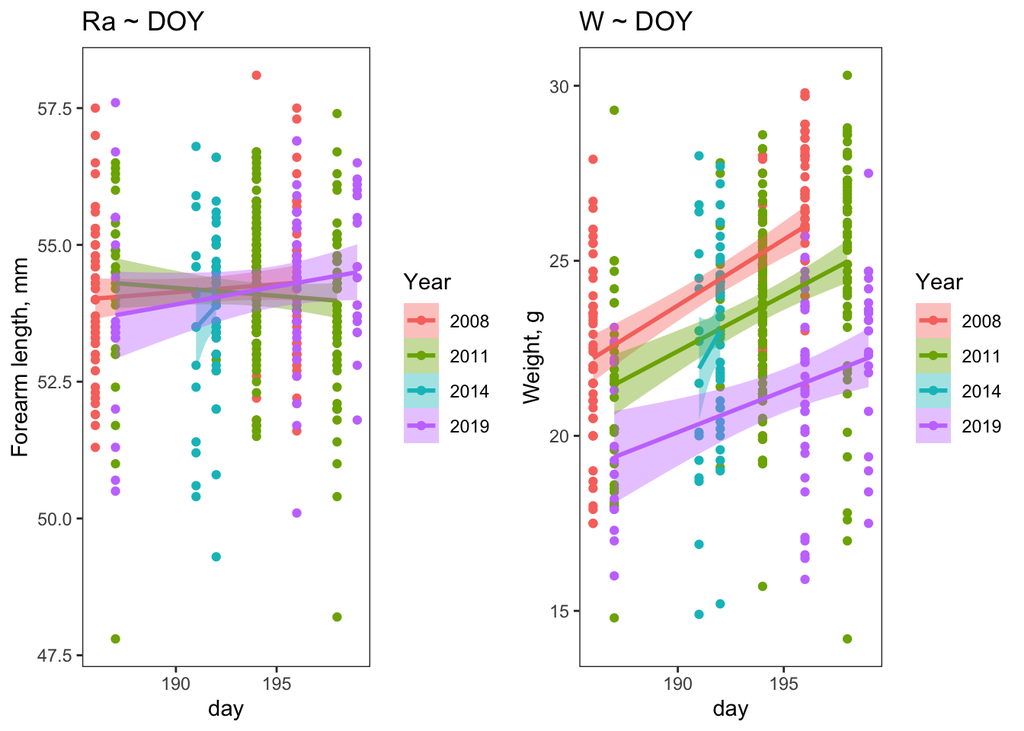

As we can see, Ra remains constant over inventory period, and probably doesn’t differ among years (need statistical testing, but gives a hint from the plot). Weight, instead, (i) differs among years, and (ii) grows over the inventory period.

In other words, bats captured later might have higher weight, regardless of spring weather conditions. To minimize an effect of time within inventory period, we calculated series of synthetic growth metrics, and test their variation over the inventory period and between the years.

Check how many bats we captured during the night

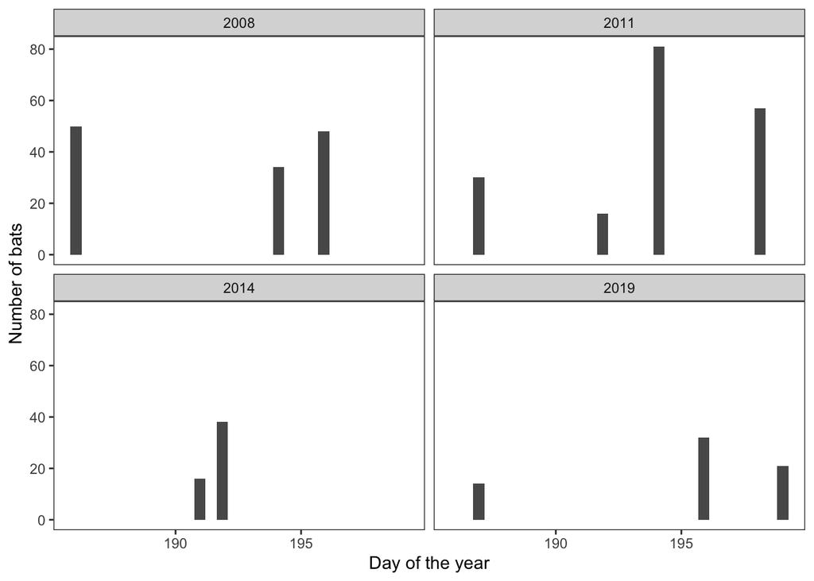

Since weight seems to grows during inventory, we substituted raw weight (g) by the residuals of body mass-day of the year regression. Body condition index (BCI) calculated as residuals from a linear regression of the logarithmically transformed weight (W) against the logarithm of the day-of-the-year (day), for each bat individual.

```r
# Fit simple linear model
mod <- lm(log(W) ~ log(day), data = df)

# Get residuals
df$BCI <- residuals(mod)

# Drop unused variables
rm(mod)
```

That way we get scaled from -1 to 1, time independent measure of body condition. Inspired by [Mikryukov et al. 2023](https://www.science.org/doi/10.1126/sciadv.adj8016), and, partly, Scaled mass index - SMI by [Peig and Green 2009](https://nsojournals.onlinelibrary.wiley.com/doi/abs/10.1111/j.1600-0706.2009.17643.x)

## Check different growth metrics for variation during inventory time

### Ra

```
## [[1]]
##      Coefficient   p_value sign_level
## 2008  0.02919669 0.2594128
## 2011 -0.02895783 0.3309957
## 2014  0.40197368 0.3898474
## 2019  0.06553997 0.1371357
##
## [[2]]
```

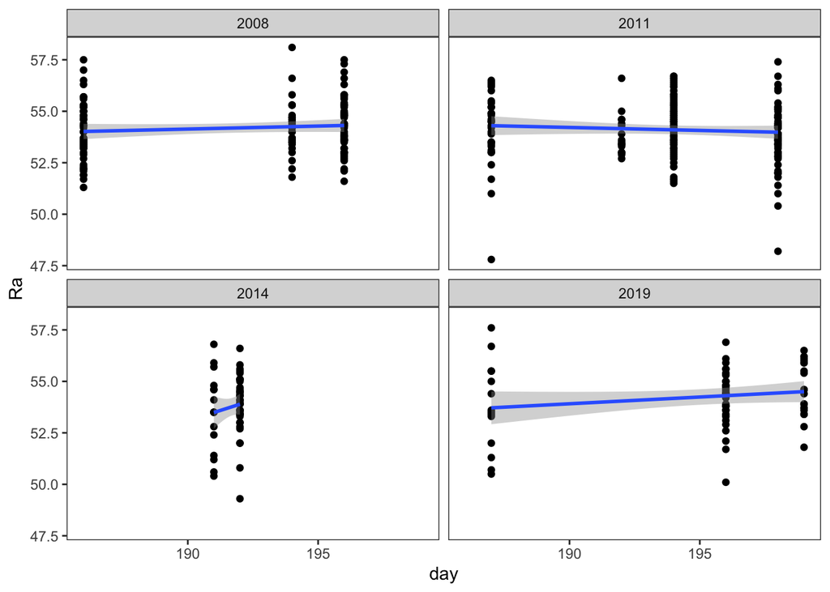

Ra is weakly related to the time of capture.

### W

```
## [[1]]
##      Coefficient      p_value sign_level
## 2008   0.3768282 3.178255e-13          *
## 2011   0.3199316 4.828581e-08          *
## 2014   1.0723684 2.287904e-01
## 2019   0.2366001 1.612522e-03          *
##
## [[2]]
```

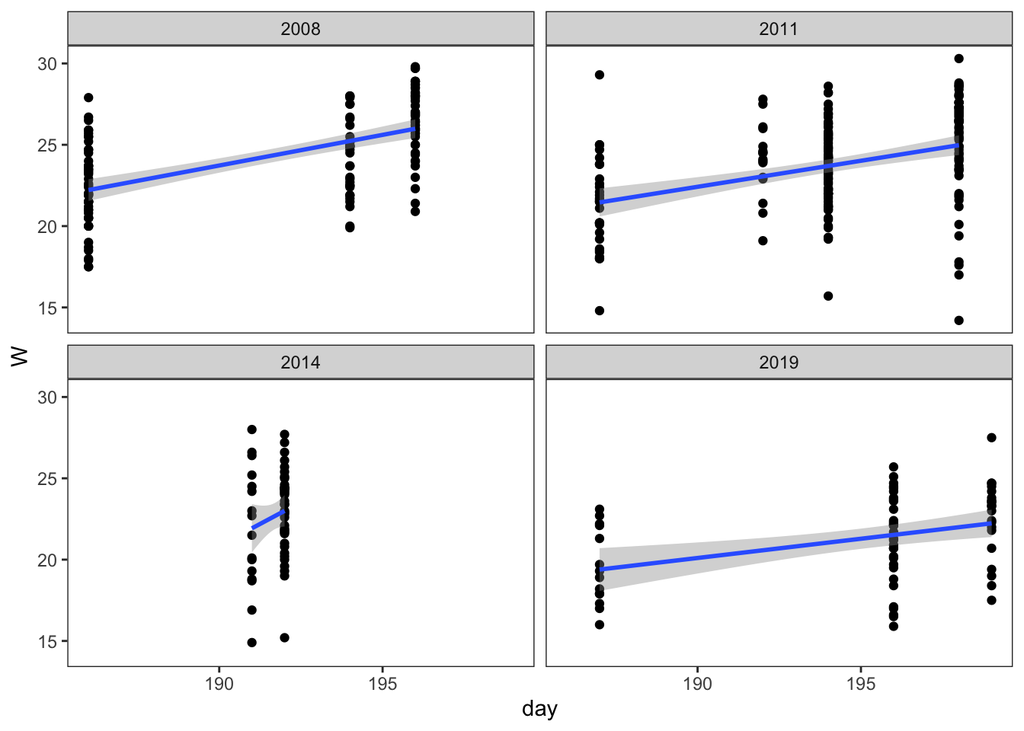

W strongly related to the time of capture.

### BCI

```r
check_my_var(df, "BCI", "day")
```

```
## [[1]]
##       Coefficient     p_value sign_level
## 2008 0.0052690642 0.008476889          *
## 2011 0.0031818157 0.206842910
## 2014 0.0450958988 0.276480575
## 2019 0.0008318491 0.812018623
##
## [[2]]
```

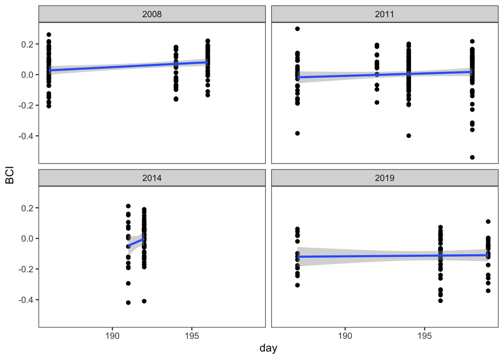

BCI is weakly related to the time of caption, as it was expected from the method of calculation.

BCI showed visual differences among years, suggesting bats grow differently depending on year-specific effects.

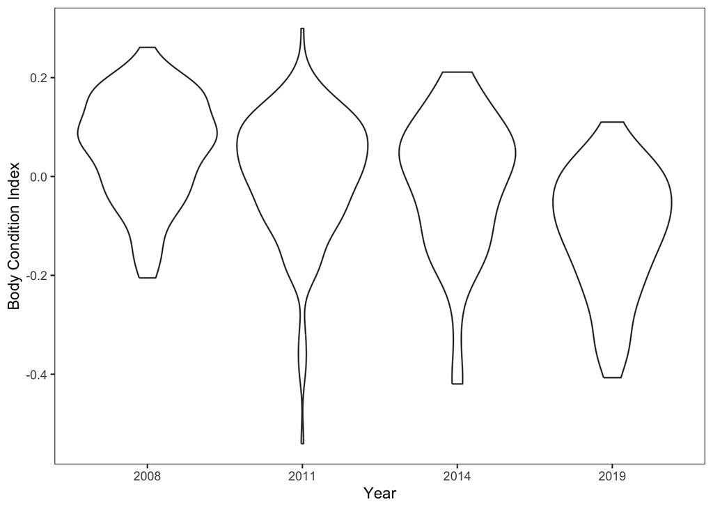

For Homilsha Forest inventory data, 2014 seems to have insufficient number of nights when 10 or more Noctule bat individuals were captured - possibly we should remove it from further analyses.

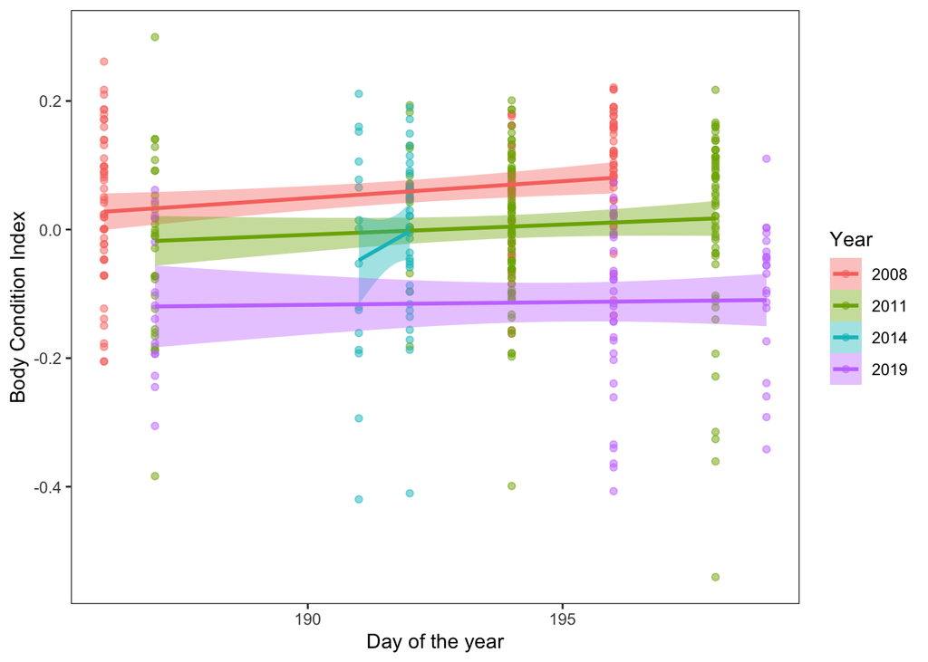

```r
ggplot(data = df, aes(day, BCI, colour = Year)) +
  geom_point(alpha = 0.5) +
  geom_smooth(method = "lm", aes(fill = Year)) +
  labs(x = "Day of the year",
       y = "Body Condition Index")
```

```r
  # facet_wrap(vars(sex))
```

Therefore, we choose to test two alternative response variables - forearm length (Ra) and Body Condition Index (BCI), as a possible growth metric in our research.

# Is there any difference in bat growth among years?

First, drop 2014 as the year with insufficient data coverage, then test the homogeneity of variance (ANOVA basic assumption).

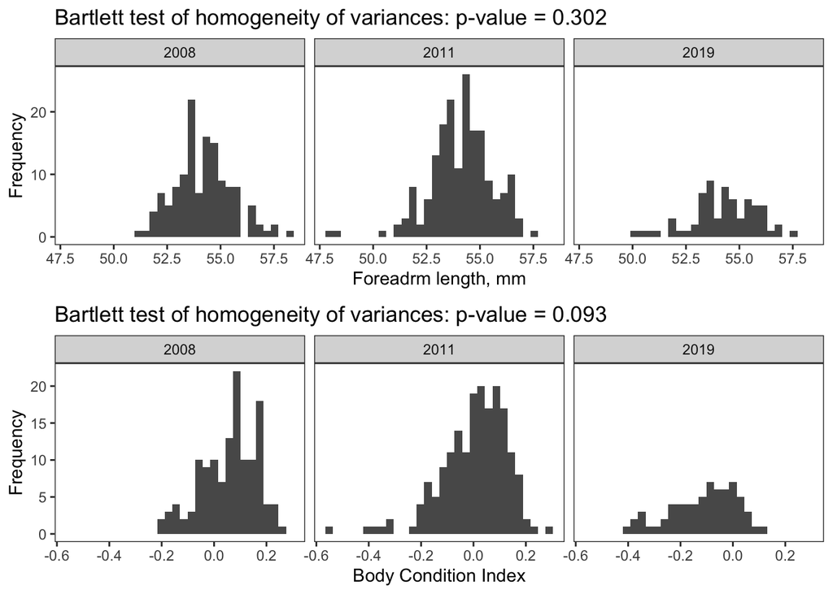

# One-way ANOVA

## Forearm length

```
##              Df Sum Sq Mean Sq F value Pr(>F)
## Year          2    1.2  0.5981   0.287   0.75
## Residuals   380  790.8  2.0810
```

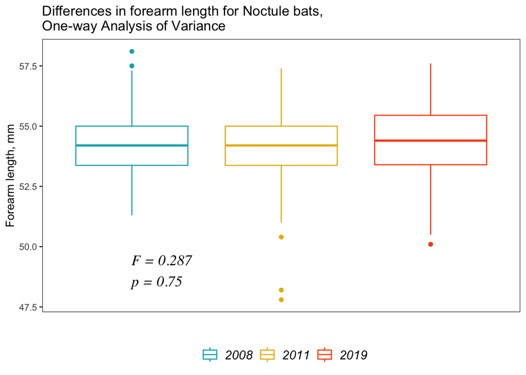

```
##   Tukey multiple comparisons of means
##     95% family-wise confidence level
##
## Fit: aov(formula = Ra ~ Year, data = df)
##
## $Year
##                  diff        lwr       upr     p adj
## 2011-2008 -0.08484848 -0.4720096 0.3023127 0.8637591
## 2019-2008  0.05843510 -0.4507155 0.5675857 0.9606021
## 2019-2011  0.14328358 -0.3410389 0.6276061 0.7659114
```

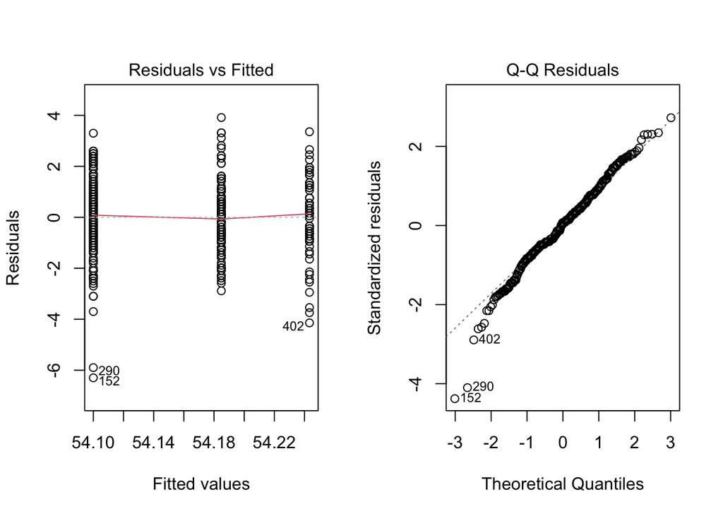

```
##
##  Shapiro-Wilk normality test
##
## data:  aov_residuals
## W = 0.98442, p-value = 0.0003828
```

We found no statistically-significant difference in average forearm length by all three years (F = 0.287, p = 0.75).

## Body Condition Index

```
##              Df Sum Sq Mean Sq F value Pr(>F)
## Year          2  1.296  0.6480   46.78 <2e-16 ***
## Residuals   380  5.264  0.0139
## ---
## Signif. codes:  0 '***' 0.001 '**' 0.01 '*' 0.05 '.' 0.1 ' ' 1
```

[figure not shown]

```
##   Tukey multiple comparisons of means
##     95% family-wise confidence level
##
## Fit: aov(formula = BCI ~ Year, data = df)
##
## $Year
##                  diff         lwr         upr    p adj
## 2011-2008 -0.05340486 -0.08499285 -0.02181687 0.000245
## 2019-2008 -0.17065872 -0.21219967 -0.12911776 0.000000
## 2019-2011 -0.11725385 -0.15676912 -0.07773859 0.000000
```

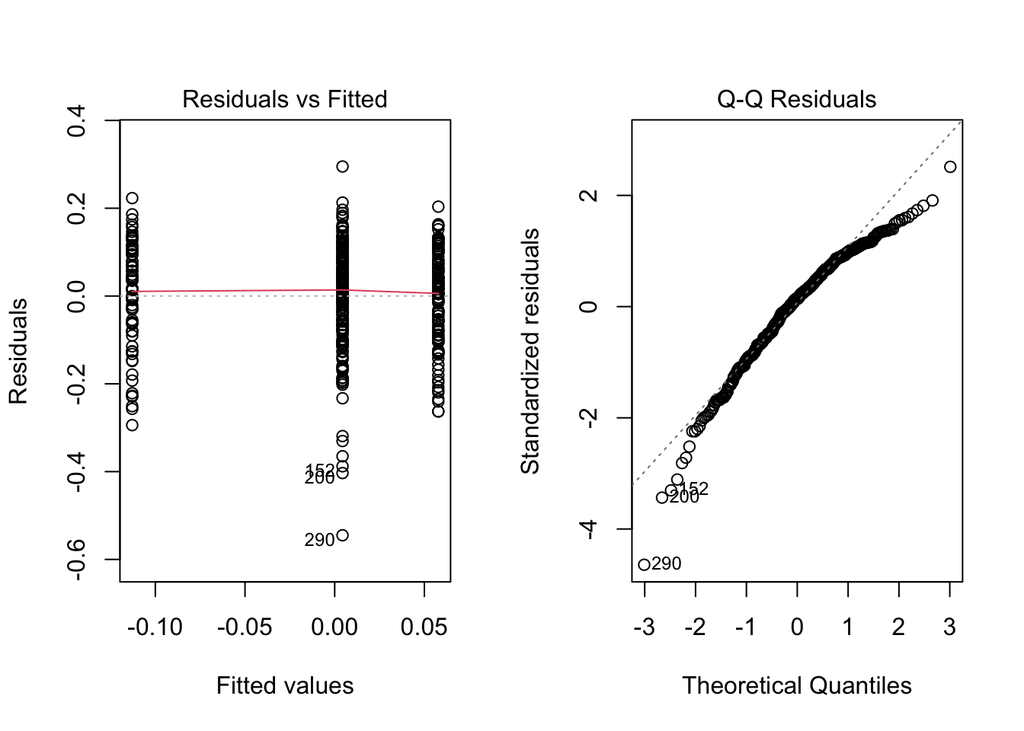

```
##
##  Shapiro-Wilk normality test
##
## data:  aov_residuals
## W = 0.96104, p-value = 1.497e-08
```

For Body Condition Index, we found a statistically-significant difference among years (F = 46.776, p < 0.001).

A Tukey post-hoc test revealed that average body condition significantly index decreased from 2008 to 2019.

Normality was not reached for the residuals (Shapiro-Wilk test), but since we have large sample size, we can neglect this fact and rely on central limit theorem and the equality of variances (Bartlett test results).

To double-check, we can fit a non-parametric Kruskal-Wallis test (use median instead of mean as mean tendency, slightly less powerful but robust to non normal distributions):

```
##
##  Kruskal-Wallis rank sum test
##
## data:  BCI by Year
## Kruskal-Wallis chi-squared = 74.259, df = 2, p-value < 2.2e-16
```

Kruskal-Wallis test confirmed the results of ANOVA, suggesting average Body Condition Index differs across years of sampling.

# Generate weather data

```r
# Take a look at the timespan
summary(df$date)
```

```
##         Min.      1st Qu.       Median         Mean      3rd Qu.         Max.
## "2008-07-04" "2008-07-14" "2011-07-13" "2011-11-22" "2011-07-17" "2019-07-18"
```

### Calculate additional weather variables

Calculate derived metrics (diurnial range, mean daily temperature, positive daily temperature). Subset only years of inventory (2008, 2011, 2014, 2019)

```r
daily <- daily %>%
   # Calculate derived metrics for each day
  mutate(DiurnialRange = Tmax - Tmin,
         MeanTemp = (Tmin + Tmax) / 2,
         # Get only positive mean temperatures (for Growing degree units calculation)
         PositiveMeanTemp = ifelse(MeanTemp > 0, MeanTemp, 0)) %>%
  # Adjust dates and add new variables for month and years
  mutate(date = as.Date(date),
         month = months(date),
         year = format(date, format = "%Y")) %>%
  # Filter only years of inventories
  filter(year %in% c(2008, 2011, 2014, 2019))
```

### Calculate GDU

Growing degree units (Sum of the mean daily temperature above 0 from the start of the year). Create custom function that calculate GDUs for each day of the year.

```r
# Must be calculated for each year separately.
# Data must contain one row per day and the variable with the positive daily mean temperature.
# If mean temperature is negative, put zero in this variable.
# Also the variable with the full date MUST be character AND named "date"
gdu <- function(daily_data_for_one_year,
                var_with_PositiveMeanTemp) {
  GDU <- list() # prepare empty list

  # looping through the daily data within the year
  for (i in 1:nrow(daily_data_for_one_year)) {
    GDU[[i]] <- c(daily_data_for_one_year$date[i],
                  sum(daily_data_for_one_year[1:i, var_with_PositiveMeanTemp])
    )
  }
  # reshape obtained list
  GDU <- as.data.frame(GDU)
  GDU <- as.data.frame(t(GDU))
  colnames(GDU) <- c("date", "GDU")
  # retrieve the result
  return(GDU)
}
```

Calculate GDU and add it to the main weather data frame.

```r
# List all required years
list_of_years <- c(2008, 2011, 2014, 2019)

# Create an empty list
gdu_by_years <- list()

for (k in 1:length(list_of_years)) {
  # Calculate GDUs for each year
  df_temp <- daily %>%
    # loop doesn't seem to work with `date` format, convert to character
    mutate(date = as.character(date)) %>%
    filter(year == list_of_years[[k]]) %>%
    select(place, date, PositiveMeanTemp) %>%
    split(.$place)

  # Create an empty list
  df_gdu <- list()

  # Loop through the list elements (data frames with all days for the particular year,
  # split by place ID)
  for (i in 1:length(df_temp)) {
    df_gdu[[i]] <- gdu(df_temp[[i]], "PositiveMeanTemp")
    df_gdu[[i]]$place <- df_temp[[i]]$place
  }

  # Transform list of data frames into a single data frame
  gdu_by_years[[k]] <- bind_rows(df_gdu)

}

# Transform list of data frames into a single data frame
GDU <- bind_rows(gdu_by_years) %>%
  mutate(date = as.Date(date))

# Add GDU as additional variable to the daily climate data for required years
daily <- daily %>%
  left_join(GDU, by = c("date", "place"))

# Drop temporary variables not longer required
rm(df_temp, df_gdu, GDU, gdu_by_years, i, k)
```

## Explore weather data

We selected two periods that are supposed to be influential for bar growth: the *spring* (March 25 - May 24) as a pre-natal period for bat pups, and the *summer* (May 25 - June 24) as an early post-natal period prior to the captures.

Since 2008 was a leap year, Julian days was different. What is March 25 for each year?

```r
daily %>%
  mutate(day = lubridate::yday(date)) %>%
  select(date, day) %>%
  filter(month(date) == 3 & day(date) == 25) %>%
  unique()
```

```
##         date day
## 1 2008-03-25  85
## 2 2011-03-25  84
## 3 2014-03-25  84
## 4 2019-03-25  84
```

Excluding dates out of those two periods

```r
# Pre-natal (spring) periods only
daily %>%
  filter(date >= "2008-03-25" & date < "2008-05-25") %>%
  mutate(season = "spring") -> spring2008

daily %>%
  filter(date >= "2011-03-25" & date < "2011-05-25") %>%
  mutate(season = "spring") -> spring2011

daily %>%
  filter(date >= "2014-03-25" & date < "2014-05-25") %>%
  mutate(season = "spring") -> spring2014

daily %>%
  filter(date >= "2019-03-25" & date < "2019-05-25") %>%
  mutate(season = "spring") -> spring2019

# Post-natal (summer) periods only
daily %>%
  filter(date >= "2008-05-25" & date < "2008-06-25") %>%
  mutate(season = "summer") -> summer2008

daily %>%
  filter(date >= "2011-05-25" & date < "2011-06-25") %>%
  mutate(season = "summer") -> summer2011

daily %>%
  filter(date >= "2014-05-25" & date < "2014-06-25") %>%
  mutate(season = "summer") -> summer2014

daily %>%
  filter(date >= "2019-05-25" & date < "2019-06-25") %>%
  mutate(season = "summer") -> summer2019

daily_spring_summer <- bind_rows(spring2008, spring2011, spring2014, spring2019,
                                 summer2008, summer2011, summer2014, summer2019)

# Remove unused temorary variables
rm(spring2008, spring2011, spring2014, spring2019,
   summer2008, summer2011, summer2014, summer2019)
```

Take a look at the minimal temperatures for springs in 2008-2019

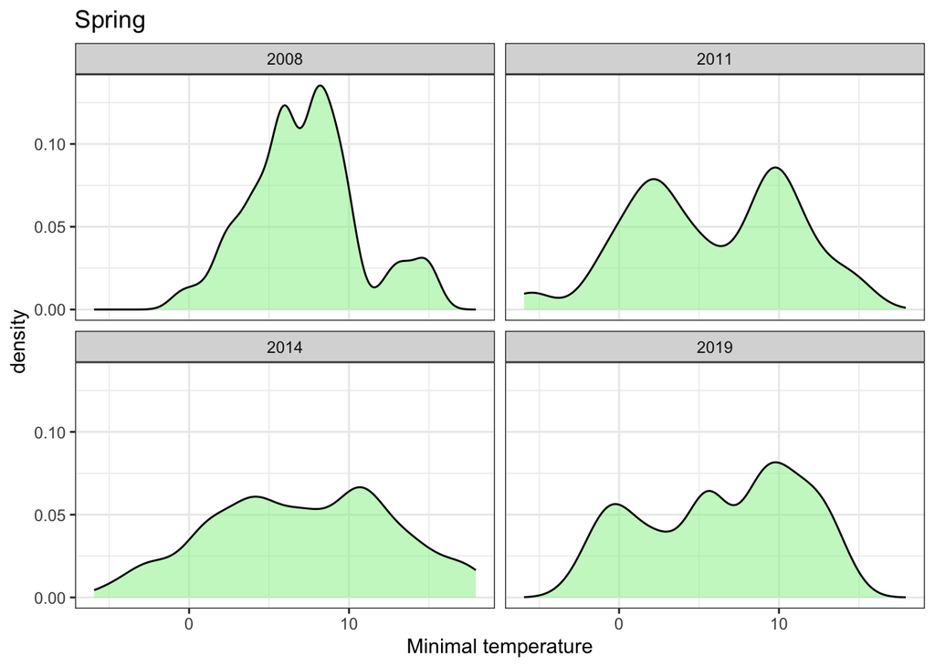

```r
daily_spring_summer %>%
  filter(season == "spring") %>%
  select(date, year, Tmin) |>
  ggplot(aes(Tmin)) +
  geom_density(fill = "lightgreen",
               alpha = 0.5) +
  facet_wrap( ~ factor(year)) +
  labs(title = "Spring",
       x = "Minimal temperature") +
  theme_bw()
```

```r
ggsave("./figures/Tmin_2008-2019_density_Spring.png", width = 16, height = 12, units = "cm", dpi = 150)
```

Take a look at the minimal temperatures for summers in 2008-2019

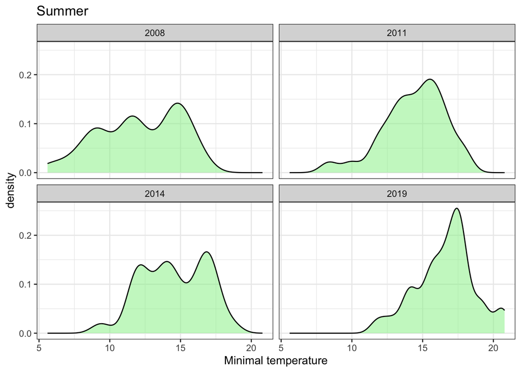

```r
daily_spring_summer |>
  filter(season == "summer") %>%
  select(date, year, Tmin) |>
  ggplot(aes(Tmin)) +
  geom_density(fill = "lightgreen",
               alpha = 0.5) +
  facet_wrap( ~ factor(year)) +
  labs(title = "Summer",
       x = "Minimal temperature") +
  theme_bw()
```

```r
ggsave("./figures/Tmin_2008-2019_density_Apr.png", width = 16, height = 12, units = "cm", dpi = 150)
```

## Generate exploratory variables for bat growth ~ weather models

```r
# Cumulative precipitation
daily_spring_summer %>%
  group_by(season, place, year) %>%
  summarise(sum(Prcp)) %>%
  rename(Prcp = 4) %>%
  as_tibble() -> Prcp_var
# Split spring only precipitation
Prcp_var %>%
  filter(season == "spring") %>%
  rename(Prcp_spr = Prcp) %>%
  select(-season) -> Prcp_spring

# Split summer only precipitation
Prcp_var %>%
  filter(season == "summer") %>%
  rename(Prcp_summ = Prcp) %>%
  select(-season) -> Prcp_summer


# Average minimum daily temperature
daily_spring_summer %>%
  group_by(season, place, year) %>%
  summarise(mean(Tmin)) %>%
  rename(Tmin = 4) %>%
  as_tibble() -> Tmin_var
# Dissect only spring minimal temperatures
Tmin_var %>%
  filter(season == "spring") %>%
  rename(Tmin_spr = Tmin) %>%
  select(-season) -> Tmin_spring

# Dissect only spring minimal temperatures
Tmin_var %>%
  filter(season == "summer") %>%
  rename(Tmin_summ = Tmin) %>%
  select(-season) -> Tmin_summer

# Number of days with mean temperature less or equal 10 Celsius degree
daily_spring_summer %>%
  filter(season == "spring") %>%
  filter(MeanTemp <= 10) %>%
  count(season, place, year) %>%
  as_tibble() %>%
  rename(Less10_var = n) %>%
  select(-season) -> Less10_var


# GDU at the end of a spring period
daily_spring_summer %>%
  filter(month(date) == 5 & day(date) == 24) %>%
  select(place, year, GDU) %>%
  rename(GDU_spr = GDU) -> GDU_spring

# GDU at the end of a summer period
daily_spring_summer %>%
  filter(month(date) == 6 & day(date) == 24) %>%
  select(place, year, GDU) %>%
  rename(GDU_summ = GDU) -> GDU_summer

# Merge weather covariates
Prcp_spring %>%
  left_join(Prcp_summer) %>%
  left_join(Tmin_spring) %>%
  left_join(Tmin_summer) %>%
  left_join(Less10_var) %>%
  left_join(GDU_spring) %>%
  left_join(GDU_summer) %>%
  rename(Place = place,
         Year = year) -> covariates
# Drop unused variables
rm(Prcp_spring, Prcp_var, Prcp_summer, Tmin_spring, Tmin_summer, Tmin_var,
   GDU_summer, GDU_spring, Less10_var, daily_spring_summer)
```

Merge weather data with bat survey data and save it for further sessions

```r
# Merge data
df_clim <- df %>%
  left_join(covariates)
# Export climate data for further sessions
save(df_clim, file = "bats_wClimate_2008-2019.Rdata")
```